# Disturbance–response analysis II — wavelet synchrony (coherence, cross-power, phase → apparent lag, amplitude)

Robust signal-processing pass: Morlet wavelet at the P≈500 band, pre vs post — the native wavelet view, read against analysis I’s moments + peaks

nic (nic@cascadeclimate.org)

2026-07-18

Analysis I described synchrony with **moments + peak spacings** over frozen `pre`/`post` windows — the simplest thing that works, but peak-finding frays on noisy/irregular signals and its lag is a coarse few-sample offset. This pass takes the **native wavelet view**: the Morlet wavelet (via **WaveletComp**) resolves synchrony jointly in **time and frequency**, so we can isolate the generator’s `P≈500` band and watch coupling evolve *through* the disturbance, not just at the settled ends. Deliberately **different metrics** from analysis I — the point is to compare what each approach sees (there is no attempt to reproduce the peak-based numbers).

Four band-localized quantities, all read at `P≈500` (the driver’s period):

- **Wavelet coherence** `∈[0,1]` — normalized (smoothed) coupling strength.
- **Cross-wavelet power** — strength of *shared* oscillation at the band (un-normalized).
- **Phase difference φ** (radians) — `Angle = phase.climate − phase.response`, the raw synchrony phase; **climate leads ⇒ positive φ**. Shown in the tables alongside its step-unit form:
- **Apparent lag** = `φ · P / (2π)` steps — φ rescaled to the interpretable “how many steps behind” (the figures use this; the tables carry both).
- **Amplitude ratio** — physical band amplitude `response / climate` (see the `×sd` note in `band_trace`: WaveletComp standardizes each channel, so the raw amplitude ratio must be rescaled back to physical units).

*Two caveats carried throughout.* **(1) COI/edge:** at period `P` the Morlet spans `~±707` steps, so band metrics are only trustworthy `≥707` steps from a series end *and* from a regime boundary — settled averages use those buffered windows, and trace edges are blanked. **(2) Uncertainty:** the band series is heavily autocorrelated, so error bars use a **block SE** — one estimate per `P`-long cycle, `SE = dispersion/√n_blocks` (a *circular* dispersion for the phase, since linear sd on wrapped angles is invalid). The COI buffer leaves only **~2 cycles per settled window** (reported as `n_blocks`), so these SEs carry ~1 degree of freedom: read them as **coarse guides** to whether an effect clears its noise, not precise intervals. Shown next to each pre→post change so effect size is read against its uncertainty.

## Helpers

```r
# All wavelet helpers now live in R/wavelet_kernel.R (sourced in setup) — edit once, not three
# times. Build THIS notebook's copies from a small config and inject them into the chunk
# environment, so every call site below stays bare (wco(df), band_trace(wc, df), plot_wc(...), ...).
# Config = the synthetic leg: band P≈500 (the synthetic "days" are plain steps), a clean strong sine
# driver (so φ is always defined — no phase gating), a `transition` phase, a time axis, no calendar
# shading. See tickets/wavelet_significance_mask.plan.md and R/wavelet_kernel.R for the full config.
list2env(make_wavelet_kernel(list(
  P_days         = P,                          # 500 — band period in the wavelet's own unit (steps)
  phase_gate     = FALSE,                       # clean strong driver ⇒ φ defined at the band everywhere
  has_transition = TRUE,                        # settled `post` starts AFTER the `transition` span
  season         = FALSE,                        # synthetic time, no calendar quarters to shade
  trace_x        = "time",
  lag_wrap_break = FALSE,
  lag_lab        = "app. lag",                   # steps, not days
  smooth_w       = 51,                           # resid-derivative smoothing window
  lowerPeriod    = function(P, df) P / 2^1.5,     # bracket the P band by ±1.5 octaves (mid-axis ridge)
  upperPeriod    = function(P, df) P * 2^1.5,
  wc_marks       = NULL,                          # no week/month/year guides (no calendar)
  dist_vline     = "grey80",
  timelab        = "time", periodlab = "period",
  x_lab          = "time",                         # trace/resid x-axis label (02 uses plain "time")
  trace_lw = 0.35, resid_lw = 0.4, dresid_lw = 0.3,  # 02's slightly thicker trace/resid lines
  resid_sub      = function(g, L, step)
    sprintf("pre-fit predictor:  log(response)(t) ≈ %.2f · climate(t − %d)", g, L)
)), environment())
```

```
## <environment: R_GlobalEnv>
```

```r
# response is analyzed in log space (log-linear generator) → add log_response once at load.
d_shift  <- read_csv("synthetic_shift.csv",  show_col_types = FALSE) %>% mutate(log_response = log(response))
d_desync <- read_csv("synthetic_desync.csv", show_col_types = FALSE) %>% mutate(log_response = log(response))
d_return <- read_csv("synthetic_return.csv", show_col_types = FALSE) %>% mutate(log_response = log(response))
```

```r
# One coherency transform per dataset → reused by every image, trace and table below.
wc_shift  <- wco(d_shift);  tr_shift  <- band_trace(wc_shift,  d_shift);  sm_shift  <- wave_summary(tr_shift)
wc_desync <- wco(d_desync); tr_desync <- band_trace(wc_desync, d_desync); sm_desync <- wave_summary(tr_desync)
wc_return <- wco(d_return); tr_return <- band_trace(wc_return, d_return); sm_return <- wave_summary(tr_return)
```

# Where the shared power lives

A significance reference for the power channel that carries the story. Un-normalized cross-power vs period, time-averaged over the whole record, against the analytic red-noise 95% level (dashed orange). It confirms the band power is **genuinely significant vs red noise** — not a smoothing artifact — the check the *normalized* coherence (saturated ≈1 everywhere, even over Desync’s noise) cannot provide. Shift and Return, coupled throughout, peak **far above red noise** at `P≈500`. Desync’s band peak is **roughly halved** (its post half is decoupled noise, contributing no band power to the whole-record average) yet still clears red noise, because its **pre** half is fully coupled — so a *whole-record average* only dents the peak. Desync’s clean collapse is **time- resolved**, not in this average: see its band-trace below, where the settled-**post** cross-power crashes toward 0 while coherence holds.

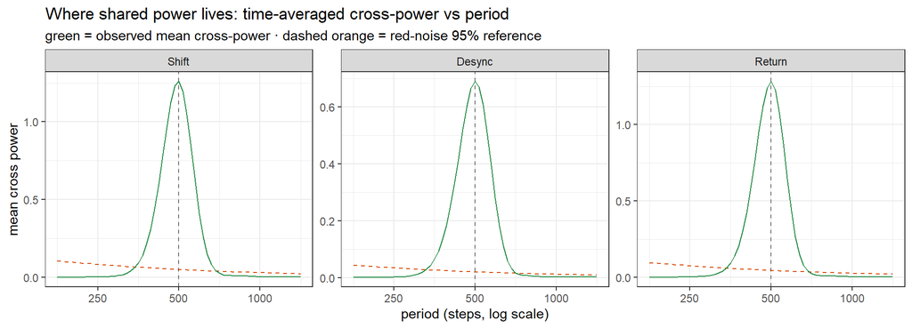

Figure 1. Time-averaged (whole-record) cross-wavelet power vs period (log x), per scenario, with the red-noise 95% reference (dashed orange; analytic AR(1), DOF-inflated for the time-average). The generator band (grey dashed, P≈500) carries a shared-power peak far above red noise in all three — coupling is real, not a coherence artifact. Shift/Return (coupled throughout) peak highest; Desync’s peak is ~halved because half its record (post) is decoupled noise, but the whole-record average still clears the reference — the full Desync collapse is time-resolved (settled-post cross-power → 0 in the band-trace), not visible in a record-long mean.

```r
xps <- bind_rows(xpower_spectrum(wc_shift,  d_shift,  "Shift"),
                 xpower_spectrum(wc_desync, d_desync, "Desync"),
                 xpower_spectrum(wc_return, d_return, "Return")) %>%
  mutate(id = factor(id, c("Shift", "Desync", "Return")))     # xpower_spectrum returns `id` (kernel)
ggplot(xps, aes(period, power)) +
  geom_vline(xintercept = P, linetype = 2, colour = "grey45") +
  geom_line(aes(period, ref), colour = "#d94801", linetype = 2, linewidth = 0.4) +   # red-noise 95%
  geom_line(colour = "#238b45", linewidth = 0.4) +
  facet_wrap(~ id, scales = "free_y") +
  scale_x_log10(breaks = c(250, 500, 1000)) +
  labs(title = "Where shared power lives: time-averaged cross-power vs period",
       subtitle = "green = observed mean cross-power · dashed orange = red-noise 95% reference",
       x = "period (steps, log scale)", y = "mean cross power")
```

# Shift

Expectation: coupling *survives* the disturbance but the regime changes — response log-amplitude halves (band amp ratio `1.0→0.5`, = β) and lag shortens (`50→10`). Wavelet reading: coherence and cross-power stay high; **apparent lag drops ~50→10** and **amplitude ratio drops ~1.0→0.5**.

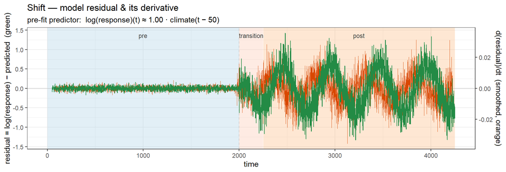

Figure 2. Shift — model residual (log(response) − pre-fit prediction, green) over the whole series with its smoothed derivative (orange, right axis); phases shaded and labelled, dashed = disturbance. Flat ~0 through pre by construction; a new nonzero regime after the disturbance.

```r
plot_resid(d_shift, "Shift — model residual & its derivative")
```

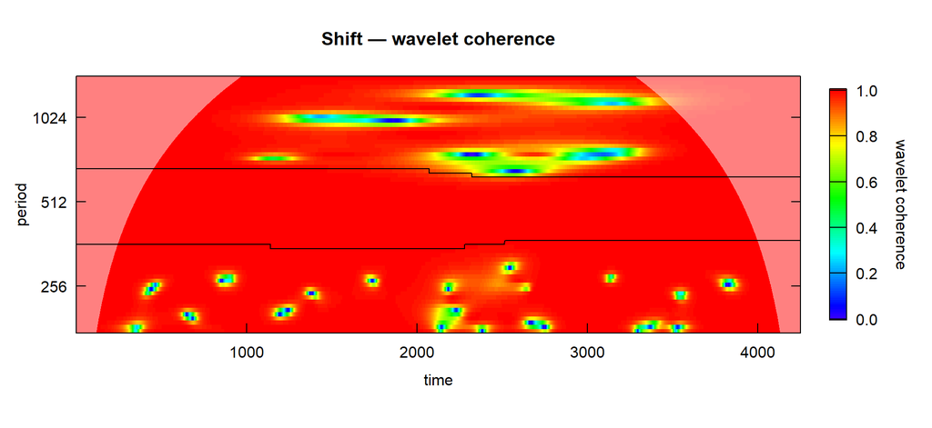

```r
plot_wc(wc_shift, d_shift, "Shift — wavelet coherence")
```

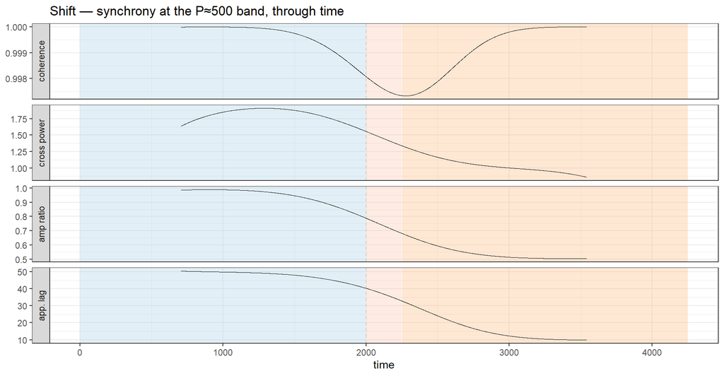

```r
plot_band_trace(tr_shift, "Shift — synchrony at the P≈500 band, through time")
```

```r
emit_table(sm_shift, "Shift — band synchrony, settled pre vs post (n_blocks = cycles the SEs rest on; SEs as error bars)")
```

Shift — band synchrony, settled pre vs post (n_blocks = cycles the SEs rest on; SEs as error bars)

| phase | n_blocks | coherence | xpower | amp_ratio | phi | lag |
| --- | --- | --- | --- | --- | --- | --- |
| pre | 2 | 1 | 1.86 | 0.98 | 0.62 | 49.60 |
| post | 2 | 1 | 0.92 | 0.51 | 0.13 | 10.37 |

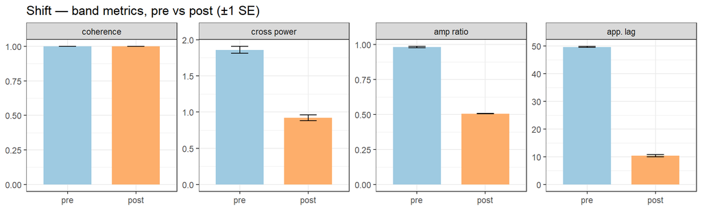

```r
plot_wave_bars(sm_shift, "Shift — band metrics, pre vs post (±1 SE)")
```

Read-off: amplitude ratio ≈ **1.0 → 0.5** and apparent lag ≈ **50 → 10** while coherence and cross-power stay high — the wavelet agrees with analysis I’s “new regime, still coupled,” and pins the lag change far more sharply than peak offsets could.

# Desync

Expectation: `post` response is stationary noise matched to regime-n *variance* — so its energy leaves the `P` band and spreads across all scales. Wavelet reading: **cross-power and amplitude ratio at the band collapse**; note whether the *normalized* coherence follows.

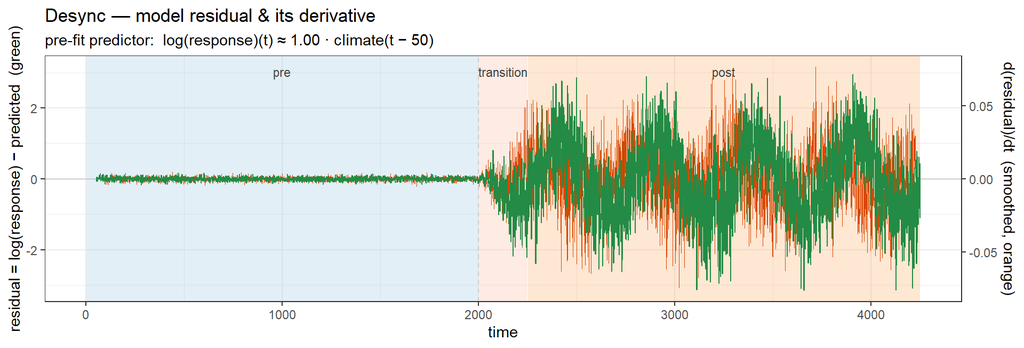

Figure 6. Desync — model residual (green) + derivative (orange, right axis), whole series; phases shaded, dashed = disturbance. Residual is ~0 noise in pre, then becomes large and erratic as the response decouples into noise.

```r
plot_resid(d_desync, "Desync — model residual & its derivative")
```

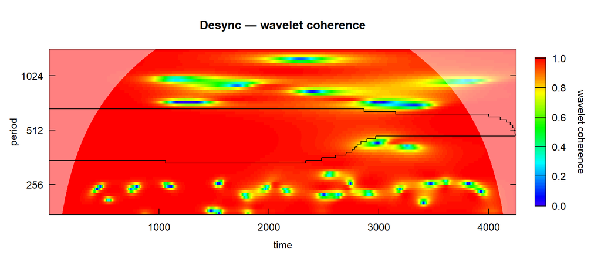

```r
plot_wc(wc_desync, d_desync, "Desync — wavelet coherence")
```

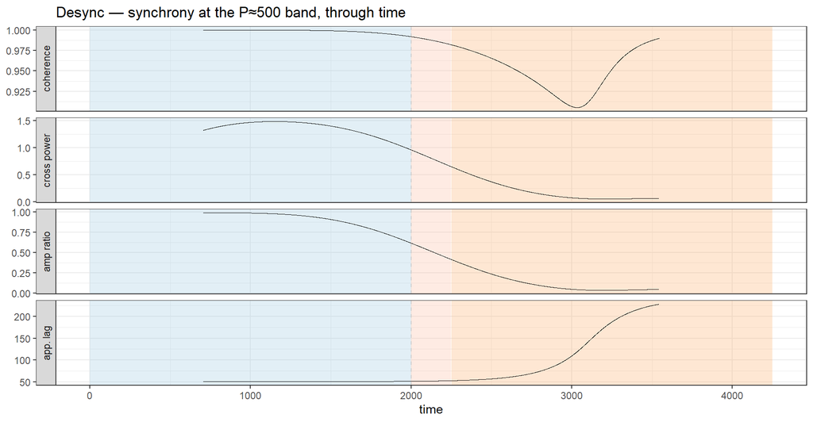

Figure 8. Desync — band metrics through time. Cross-power and amplitude ratio crash toward 0 after the disturbance while coherence stays high — the decoupling shows in POWER, not coherence.

```r
plot_band_trace(tr_desync, "Desync — synchrony at the P≈500 band, through time")
```

```r
emit_table(sm_desync, "Desync — band synchrony, settled pre vs post (n_blocks = cycles the SEs rest on)")
```

Desync — band synchrony, settled pre vs post (n_blocks = cycles the SEs rest on)

| phase | n_blocks | coherence | xpower | amp_ratio | phi | lag |
| --- | --- | --- | --- | --- | --- | --- |
| pre | 2 | 1.00 | 1.46 | 0.97 | 0.63 | 50.32 |
| post | 2 | 0.96 | 0.06 | 0.04 | 2.48 | 197.24 |

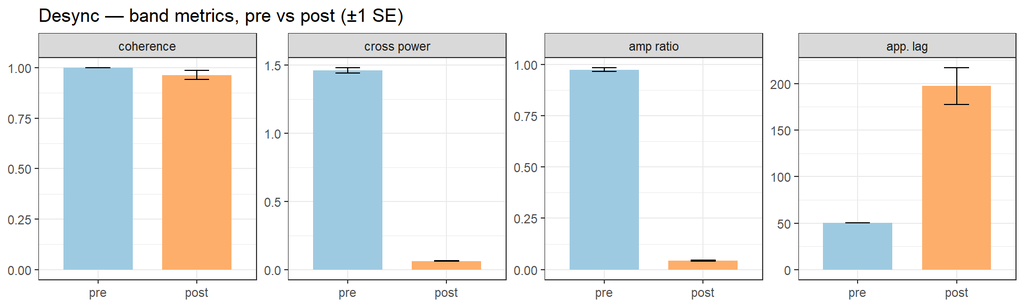

Figure 9. Desync — pre vs post band metrics, ±1 SE. Cross-power and amplitude ratio collapse (well beyond their SEs); coherence stays high and the apparent lag SE balloons (phase no longer stable) — its residual value is meaningless.

```r
plot_wave_bars(sm_desync, "Desync — band metrics, pre vs post (±1 SE)")
```

Read-off: the key limitation of the **native** view — WaveletComp’s *normalized, smoothed* coherence stays near 1 even though the response is noise, and a phase/lag is still numerically returned (with a huge SE). What actually registers the decoupling is the **un-normalized cross-power and the band amplitude ratio collapsing to ≈0**: the response no longer oscillates at the climate period. (Analysis I caught the same event via peak-spacing irregularity — a different fingerprint of the same decoupling.)

# Return

Expectation: the response **decouples into noise then recovers** to **regime n**, so `pre` and `post` are the same regime — every settled band metric should match end-to-end. The transition itself is a **transient decoupling** (like Desync, but recovering): the P≈500 band power dips then returns.

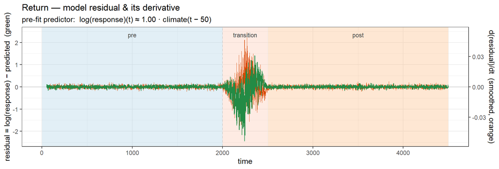

Figure 10. Return — model residual (green) + derivative (orange, right axis), whole series; phases shaded, dashed = disturbance. Residual departs during the decoupling (derivative spikes at onset and recovery) then settles back to ~0.

```r
plot_resid(d_return, "Return — model residual & its derivative")
```

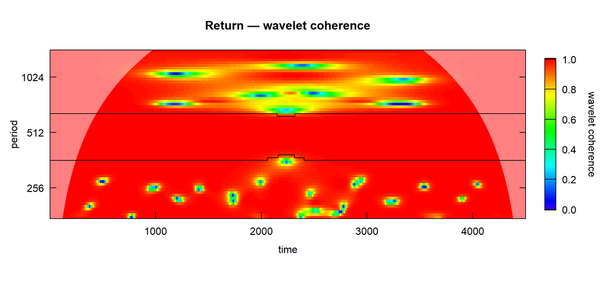

Figure 11. Return — wavelet coherence spectrum. Coupling is coherent in pre and post (both regime n); within the transition the P≈500 band power dips as the response decouples into noise, then recovers — normalized coherence stays high (smoothing), as in Desync.

```r
plot_wc(wc_return, d_return, "Return — wavelet coherence")
```

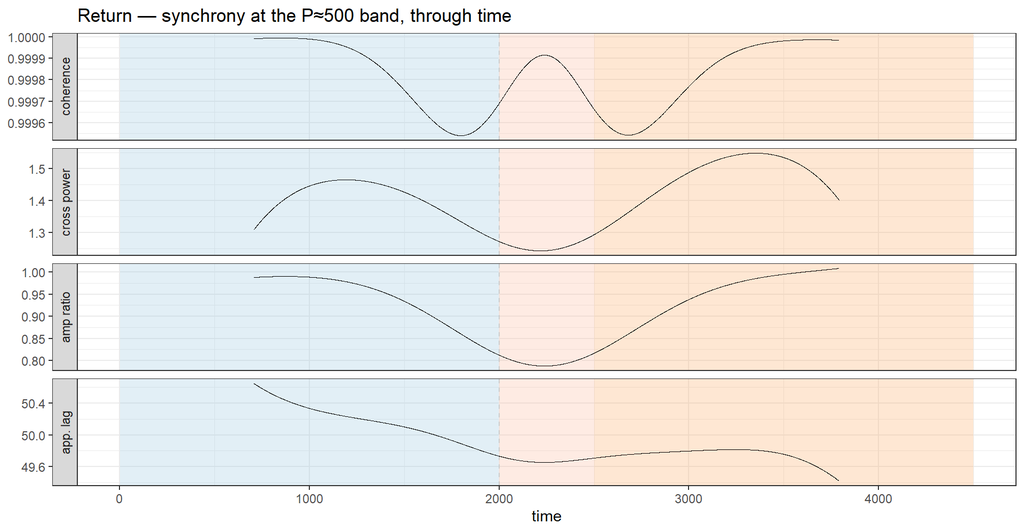

Figure 12. Return — band metrics through time. Cross-power and amplitude ratio dip during the transition (transient decoupling — attenuated by Morlet smearing over the short window, so shallower than Desync’s permanent collapse) while coherence stays high, then all four recover to their pre values by the settled post window.

```r
plot_band_trace(tr_return, "Return — synchrony at the P≈500 band, through time")
```

```r
emit_table(sm_return, "Return — band synchrony, settled pre vs post (n_blocks = cycles the SEs rest on)")
```

Return — band synchrony, settled pre vs post (n_blocks = cycles the SEs rest on)

| phase | n_blocks | coherence | xpower | amp_ratio | phi | lag |
| --- | --- | --- | --- | --- | --- | --- |
| pre | 2 | 1 | 1.44 | 0.98 | 0.63 | 50.30 |
| post | 2 | 1 | 1.48 | 1.00 | 0.62 | 49.62 |

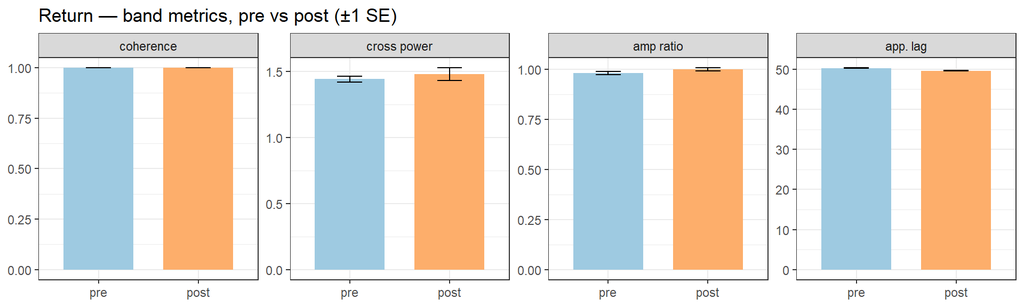

```r
plot_wave_bars(sm_return, "Return — band metrics, pre vs post (±1 SE)")
```

Read-off: pre ≈ post on all four band metrics — the disturbance leaves **no lasting wavelet signature** (matching analysis I’s null result), even though the transition itself is a brief decoupling — a transient Desync that recovers.

# Cross-dataset summary

Post-minus-pre change in the four band metrics, per scenario, each Δ carrying its propagated SE (`√(se_pre² + se_post²)`) so the change is read against its uncertainty.

```r
sm_all <- bind_rows(Shift = sm_shift, Desync = sm_desync, Return = sm_return, .id = "dataset")

# Long form (metric × value × se) via the shared reshape, then pre→post delta + propagated SE.
delta <- metrics_long(sm_all, c("dataset", "phase")) %>%
  pivot_wider(names_from = phase, values_from = c(value, se)) %>%
  mutate(delta    = value_post - value_pre,
         delta_se = sqrt(se_pre^2 + se_post^2),
         dataset  = factor(dataset, c("Shift", "Desync", "Return")))
```

```r
cat(kable(delta %>% transmute(dataset, metric = metric_labs[as.character(metric)],
                              pre = value_pre, post = value_post, delta, delta_se),
          digits = 2, caption = "pre → post change in band metrics, all datasets (delta_se = propagated ±1 SE)"), sep = "\n")
```

pre → post change in band metrics, all datasets (delta_se = propagated ±1 SE)

| dataset | metric | pre | post | delta | delta_se |
| --- | --- | --- | --- | --- | --- |
| Shift | coherence | 1.00 | 1.00 | 0.00 | 0.00 |
| Shift | cross power | 1.86 | 0.92 | -0.94 | 0.06 |
| Shift | amp ratio | 0.98 | 0.51 | -0.48 | 0.01 |
| Shift | app. lag | 49.60 | 10.37 | -39.23 | 0.42 |
| Desync | coherence | 1.00 | 0.96 | -0.04 | 0.02 |
| Desync | cross power | 1.46 | 0.06 | -1.40 | 0.02 |
| Desync | amp ratio | 0.97 | 0.04 | -0.93 | 0.01 |
| Desync | app. lag | 50.32 | 197.24 | 146.92 | 19.74 |
| Return | coherence | 1.00 | 1.00 | 0.00 | 0.00 |
| Return | cross power | 1.44 | 1.48 | 0.04 | 0.05 |
| Return | amp ratio | 0.98 | 1.00 | 0.02 | 0.01 |
| Return | app. lag | 50.30 | 49.62 | -0.68 | 0.11 |

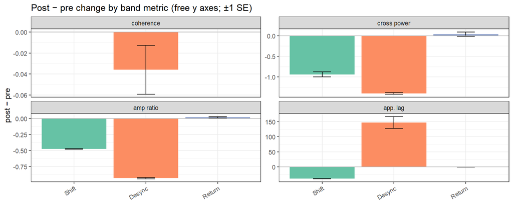

Figure 14. Post − pre change per scenario, faceted by band metric with free y axes (so scenarios compare within each metric, not across metrics), ±1 propagated SE. Shift = amp-ratio & lag drop (coupled regime shift); Desync = cross-power & amp-ratio collapse (decoupling, invisible to coherence); Return = all Δ ≈ 0.

```r
ggplot(delta, aes(dataset, delta, fill = dataset)) +
  geom_col() +
  geom_errorbar(aes(ymin = delta - delta_se, ymax = delta + delta_se), width = 0.25, colour = "black", na.rm = TRUE) +
  geom_hline(yintercept = 0, colour = "grey70") +
  facet_wrap(~ metric, scales = "free_y", labeller = as_labeller(metric_labs)) +
  scale_fill_brewer(palette = "Set2", guide = "none") +
  labs(title = "Post − pre change by band metric (free y axes; ±1 SE)", x = NULL, y = "post − pre") +
  theme(axis.text.x = element_text(angle = 30, hjust = 1))
```

**Takeaways — the native wavelet view, next to analysis I.** The Morlet band reading pins the **Shift** cleanly: amplitude ratio and apparent lag move together (1.0→0.5, 50→10) while coherence holds — the same “coupled regime shift” analysis I inferred, but with a sharp, sub-step lag instead of a few-sample peak offset. **Return** is a flat null in the settled view (its transition is a brief decoupling that fully recovers — a transient Desync). The instructive disagreement is **Desync**: the wavelet’s *normalized* coherence is **fooled** (stays ≈1, and still hands back a phase/lag), so the decoupling reads only in the **un-normalized cross-power and band amplitude** collapsing to ≈0 — where analysis I saw it as peak-spacing irregularity. Two methods, two fingerprints of the same event: the lesson is that *coherence alone is not enough* — you need a power/amplitude channel to see a driver the response has stopped tracking (a significance test wouldn’t rescue it: the saturated coherence would itself read as “significant”). ```